# Challenge #2

This notebook contains the results of the Smarthelio challenge #2. It is divided in 2 main parts:

```
1 Features and initial moment of the failure
2 Possible solutions
```

For more details in regards this results, please contact the author of this notebook.

NOTE: all the results here contained, are for the to be used exclusively for the Smarthelio challenge.

## 1 Features and initial moment of the failure

### Imports:

```python
# import libraries
import pandas as pd
import numpy as np
import matplotlib.pyplot as plt
import seaborn as sns;sns.set_style("whitegrid")
import warnings
warnings.filterwarnings('ignore')
import sys
from os.path import join
%matplotlib inline
```

```python
# define raw data file
file = join(r"D:\Users\dguzmanr\Desktop\smarthelio\data\Challenge2.xlsx")
# define code path
sys.path.append(r"D:\Users\dguzmanr\Desktop\smarthelio\notebooks\code")
```

```python
# import challenge 1 functions
import read_data
import calcs
```

### Read raw data and create DF

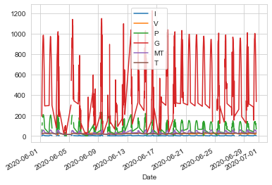

```python
df = read_data.read_data(file)
df.plot()
```

### PR

```python
pnom = 245  # according to the .xls file
temp_coef = -0.42  # according to the .xls file
df["PR"] = calcs.pr(df=df,
                    p_col="P",
                    irr_col="G",
                    temp_col="MT",
                    pnom=pnom,
                    temp_coef=temp_coef)
df.head()
```

| Date | I | V | P | G | MT | T | Clear Sky | PR |
| --- | --- | --- | --- | --- | --- | --- | --- | --- |
| 2020-06-01 06:30:00 | 1.168 | 26.5 | 30.9520 | 191.587644 | 18.326667 | 15.6 | False | 0.641431 |
| 2020-06-01 07:00:00 | 2.377 | 25.9 | 61.5643 | 394.809626 | 27.870000 | 17.6 | True | 0.644231 |
| 2020-06-01 07:27:00 | NaN | NaN | NaN | 499.719828 | 33.828333 | 18.4 | True | NaN |
| 2020-06-01 07:30:00 | 3.694 | 28.3 | 104.5402 | 510.039511 | 34.735000 | 18.7 | True | 0.872255 |
| 2020-06-01 08:00:00 | 4.661 | 27.7 | 129.1097 | 611.360316 | 39.269492 | 19.3 | True | 0.916930 |

### Resistance calc

By definition electrical resistance = V / I

```python
df["R"] = df.V / df.I
df.head()
```

| Date | I | V | P | G | MT | T | Clear Sky | PR | R |
| --- | --- | --- | --- | --- | --- | --- | --- | --- | --- |
| 2020-06-01 06:30:00 | 1.168 | 26.5 | 30.9520 | 191.587644 | 18.326667 | 15.6 | False | 0.641431 | 22.688356 |
| 2020-06-01 07:00:00 | 2.377 | 25.9 | 61.5643 | 394.809626 | 27.870000 | 17.6 | True | 0.644231 | 10.896088 |
| 2020-06-01 07:27:00 | NaN | NaN | NaN | 499.719828 | 33.828333 | 18.4 | True | NaN | NaN |
| 2020-06-01 07:30:00 | 3.694 | 28.3 | 104.5402 | 510.039511 | 34.735000 | 18.7 | True | 0.872255 | 7.661072 |
| 2020-06-01 08:00:00 | 4.661 | 27.7 | 129.1097 | 611.360316 | 39.269492 | 19.3 | True | 0.916930 | 5.942931 |

### Check plot (normalized values)

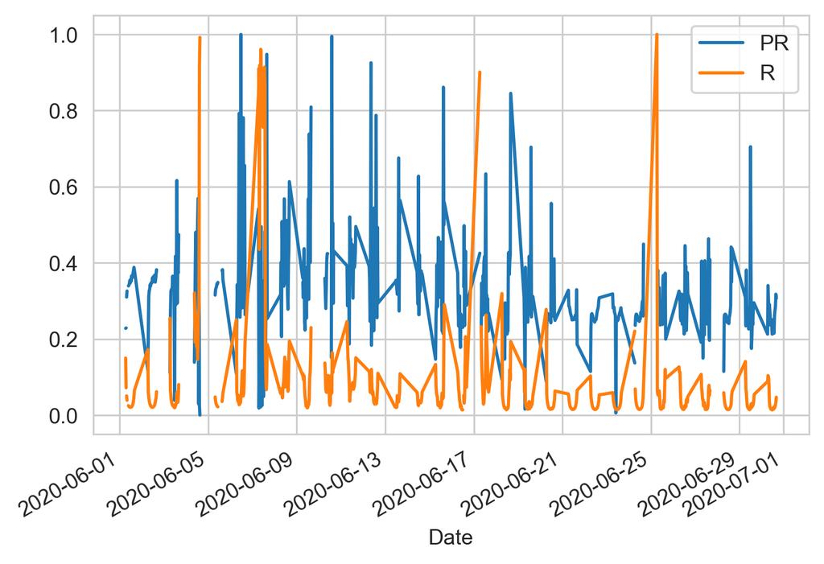

```python
fig, axes = plt.subplots(dpi=300)
PRn = df.PR / df.PR.max()
Rn = df.R / df.R.max()
PRn.plot()
Rn.plot()
plt.legend()
```

From the plots above, I was expecting to find an agreement between the PR and the increase of the resistance. However, at first seem like there is non. Therefore, I will focus on the resistance analysis:

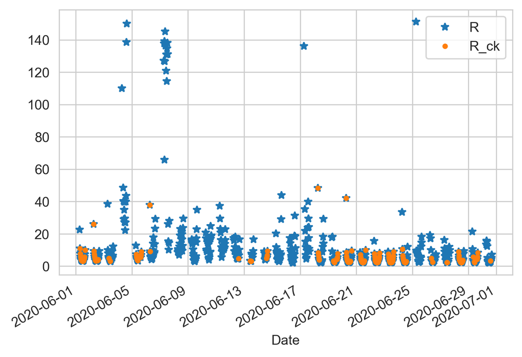

```python
R_ck = df.R.loc[df["Clear Sky"]]
fig, axes = plt.subplots(dpi=300)
df.R.plot(style="*", label="R")
R_ck.plot(style=".", label="R_ck")
plt.legend()
```

Based on the plot above, one can think that the failure could be detected in non-clearsky moments. For that, I can propose the following solutions:

## 2 Possible solutions

### Solution #1

One can set simply a threshold basd on the maximum value of the resistance at clear sky moments (R_ck). That would look like this:

```python
# naming f1
df["f1"] = np.where(df.R > R_ck.max(), 1, 0)
df.head()
```

[output not shown]

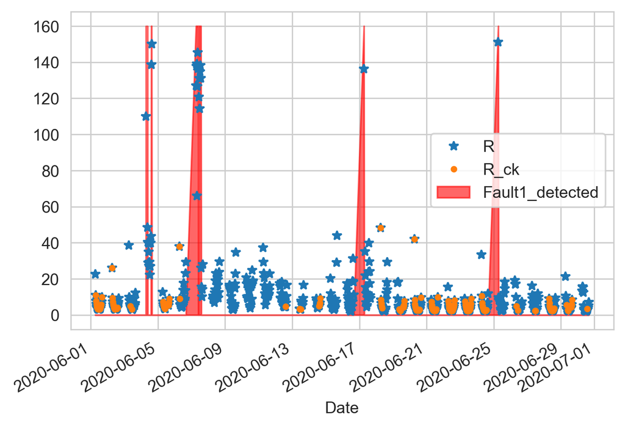

```python
fig, axes = plt.subplots(dpi=300)
df.R.plot(style="*", label="R")
R_ck.plot(style=".", label="R_ck")
axes.fill_between(df.index,
                     (160 * df.f1.values),
                         alpha=0.6, label="Fault1_detected", color="red")
plt.legend()
```